# MidTerm

Author

Santiago Roman

Published

October 4, 2025

# MIDTERM

## Problema de Regresión

### Import libraries

```python
import numpy as np
import pandas as pd
import matplotlib.pyplot as plt

from sklearn.datasets import fetch_california_housing
from sklearn.model_selection import train_test_split, learning_curve
from sklearn.linear_model import LinearRegression
from sklearn.pipeline import Pipeline
from sklearn.preprocessing import StandardScaler
from sklearn.metrics import mean_squared_error, r2_score, mean_absolute_error
```

### Cargar Data

```python
housing = fetch_california_housing()
X, y = housing.data, housing.target

print("Shape X:", X.shape, "Shape y:", y.shape)
```

```
Shape X: (20640, 8) Shape y: (20640,)
```

### Split Data

```python
X_train, X_test, y_train, y_test = train_test_split(X, y, test_size=0.2, random_state=42)
```

### Crear Pipeline

```python
reg_pipe = Pipeline([
    ("scaler", StandardScaler()),
    ("regressor", LinearRegression())
])
```

### Entrenar modelo

```python
reg_pipe.fit(X_train, y_train)
```

```
Pipeline(steps=[('scaler', StandardScaler()),
                ('regressor', LinearRegression())])
```

### Predecir

```python
y_prep_pipe = reg_pipe.predict(X_test)
```

### Resultados

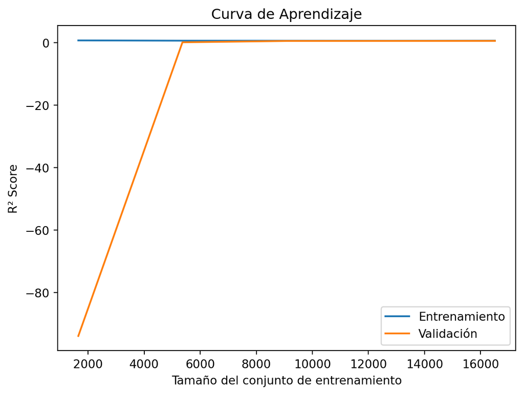

```python
train_sizes, train_scores, test_scores = learning_curve(
    reg_pipe, X, y, cv=5, scoring="r2", n_jobs=1
)

train_mean = np.mean(train_scores, axis=1)
test_mean = np.mean(test_scores, axis=1)

plt.plot(train_sizes, train_mean, label="Entrenamiento")
plt.plot(train_sizes, test_mean, label="Validación")
plt.xlabel("Tamaño del conjunto de entrenamiento")
plt.ylabel("R² Score")
plt.title("Curva de Aprendizaje")
plt.legend()
plt.show()
```

La curva de aprendizaje se realizo tomando en cuenta el valor R2 el cual representa el porcentaje del comportamiento de los datos que el modelo logra entender. mostrando que el modelo aprende los patrones para poder hacer predicciones.

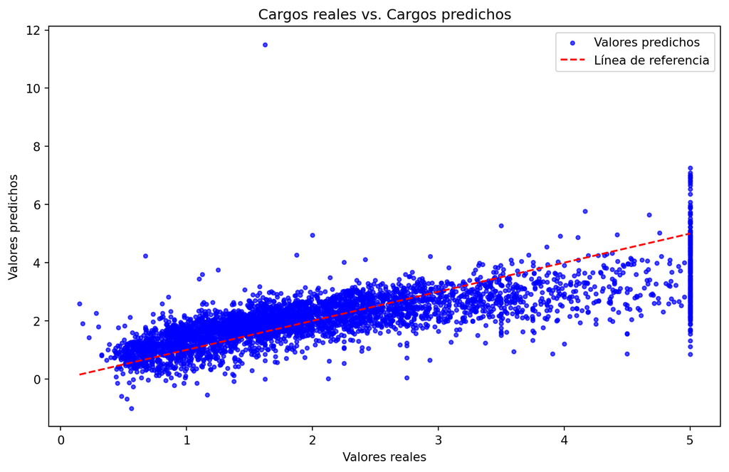

```python
plt.figure(figsize=(10, 6))
plt.scatter(y_test, y_prep_pipe, color='blue', alpha=0.7, s=10)
plt.title('Cargos reales vs. Cargos predichos')
plt.xlabel('Valores reales')
plt.ylabel('Valores predichos')
plt.plot([min(y_test), max(y_test)], [min(y_test), max(y_test)], color='red', linestyle='--')  # Línea de referencia
plt.legend(['Valores predichos', 'Línea de referencia'])
plt.show()
```

Esta grafica muestra la distribución de los datos al hacer la regresión lineal, donde se muestra los valores predichos y valores reales, además de una linea de referencia que muestra cuando los datos son predichos correctamente. En este caso los puntos se agrupan cerca de la linea de referencia aunque con cierta dispersión, lo cual muestra que el modelo acierta de forma general en gran parte de los datos, pero tiene errores en valores extremos.

```python
mae = mean_absolute_error(y_test, y_prep_pipe)
print(f"Error medio absoluto (MAE): {mae:.3f}")
```

```
Error medio absoluto (MAE): 0.533
```

### Prediccion

Se usa un nuevo registro para mostrar como funciona la prediccion.

```python
nuevo_registro = pd.DataFrame([[
    8.3252,   # MedInc - ingreso medio
    41.0,     # HouseAge - edad promedio de las casas
    6.9841,   # AveRooms - promedio de habitaciones
    1.0238,   # AveBedrms - promedio de dormitorios
    322.0,    # Population - población
    2.5556,   # AveOccup - ocupación promedio
    37.88,    # Latitude
    -122.23   # Longitude
]], columns=housing.feature_names)

prediccion = reg_pipe.predict(nuevo_registro)
print(f'Predicción del valor medio de la vivienda: ${prediccion[0]* 100000:.2f}')
```

```
Predicción del valor medio de la vivienda: $415193.84
```

[output not shown]

## Problema de Clasificación

### Import libraries

```python
from sklearn.datasets import load_breast_cancer
from sklearn.linear_model import LogisticRegression
from sklearn.metrics import accuracy_score, precision_score, recall_score, f1_score, confusion_matrix, RocCurveDisplay,ConfusionMatrixDisplay

import seaborn as sns
import pandas as pd
```

### Load Data

```python
url = "https://raw.githubusercontent.com/jbrownlee/Datasets/master/pima-indians-diabetes.csv"

# Según el dataset, las columnas serían:
col_names = ["Pregnancies", "Glucose", "BloodPressure", "SkinThickness",
            "Insulin", "BMI", "DiabetesPedigreeFunction", "Age", "Outcome"]
df = pd.read_csv(url, header=None, names=col_names)

cols_with_zeros = ["Glucose", "BloodPressure", "SkinThickness", "Insulin", "BMI"]
df[cols_with_zeros] = df[cols_with_zeros].replace(0, np.nan)
df = df.dropna()

X = df.drop("Outcome", axis=1).values
y = df["Outcome"].values
```

### Split Data

```python
X_train, X_test, y_train, y_test = train_test_split(X, y, test_size=0.2, random_state=42)
```

### Crear Pipeline

```python
clf_pipe = Pipeline([
    ("scaler", StandardScaler()),
    ("classifier", LogisticRegression(max_iter=500))
])
```

### Entrenar modelo

```python
clf_pipe.fit(X_train, y_train)
```

```
Pipeline(steps=[('scaler', StandardScaler()),
                ('classifier', LogisticRegression(max_iter=500))])
```

### Predecir

```python
y_prep_pipe = clf_pipe.predict(X_test)
```

### Evaluación

```python
print("Accuracy:", accuracy_score(y_test, y_prep_pipe))
print("Precision:", precision_score(y_test, y_prep_pipe))
print("Recall:", recall_score(y_test, y_prep_pipe))
print("F1 Score:", f1_score(y_test, y_prep_pipe))
```

```
Accuracy: 0.7721518987341772
Precision: 0.6956521739130435
Recall: 0.5925925925925926
F1 Score: 0.64
```

### Matriz de confusión

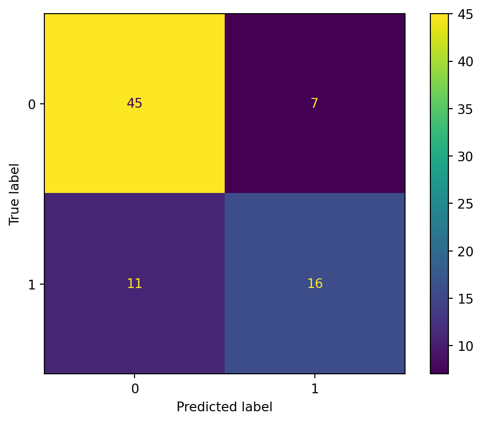

```python
ConfusionMatrixDisplay.from_predictions(y_test,y_prep_pipe)
```

### Curva ROC

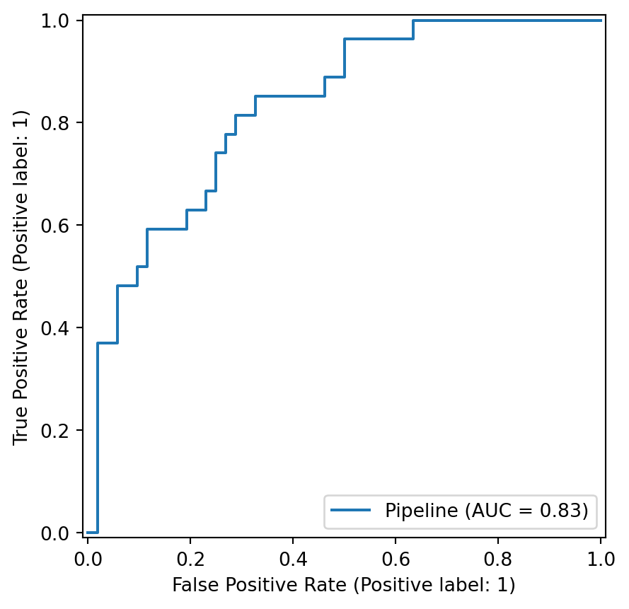

```python
RocCurveDisplay.from_estimator(clf_pipe, X_test, y_test)
plt.show()
```

La Curva ROC evalúa el rendimiento del modelo de clasificación mostrando la relación entre la Tasa de Verdaderos Positivos y la Tasa de Falsos Positivos en diferentes umbrales de decisión. El modelo obtiene un AUC de 0.83, lo que indica un 83% de probabilidad de clasificar correctamente un caso positivo por encima de uno negativo, siendo considerado un rendimiento bueno.